# U.S. Storm Event Analysis - 1985

ANA 515 Assignment III

Anbazhagan Naresh

June 21, 2024

### Synopsis:

This analysis explores storm events in the United States for the year 1985 using data from NOAA’s Storm Events Database. The dataset includes major weather-related storm events with details such as start and end dates, location, associated deaths, injuries, property damage, and other characteristics. The objective is to understand the distribution and characteristics of these events across different states, regions, and seasons. The raw dataset is linked to the below table:

|  | begin_yearmonth | episode_id | state | state_fips | cz_name | cz_fips | event_type | fips |
| --- | --- | --- | --- | --- | --- | --- | --- | --- |
| 1 | 198509 |  | Alabama | 001 | Montgomery | 101 | Thunderstorm Wind | 001101 |
| 2 | 198503 |  | Alabama | 001 | Henry | 067 | Hail | 001067 |
| 3 | 198503 |  | Alabama | 001 | Bibb | 007 | Thunderstorm Wind | 001007 |
| 4 | 198503 |  | Alabama | 001 | Lawrence | 079 | Hail | 001079 |
| 5 | 198503 |  | Alabama | 001 | Lawrence | 079 | Hail | 001079 |
| 6 | 198504 |  | Alabama | 001 | Lauderdale | 077 | Thunderstorm Wind | 001077 |
| 7 | 198504 |  | Alabama | 001 | Lauderdale | 077 | Thunderstorm Wind | 001077 |
| 8 | 198504 |  | Alabama | 001 | Colbert | 033 | Thunderstorm Wind | 001033 |
| 9 | 198504 |  | Alabama | 001 | Lauderdale | 077 | Thunderstorm Wind | 001077 |
| 10 | 198504 |  | Alabama | 001 | Franklin | 059 | Thunderstorm Wind | 001059 |

[output cut: 7969 more lines]

The data was filtered to include only events listed by county FIPS, state and county names were converted to title case, and FIPS codes were padded to ensure consistency. The data was then merged with additional state information (area and region).

| state | events | area | region |
| --- | --- | --- | --- |
| Alabama | 335 | 51609 | South |
| Arizona | 24 | 113909 | West |
| Arkansas | 283 | 53104 | South |
| California | 8 | 158693 | West |
| Colorado | 140 | 104247 | West |
| Connecticut | 15 | 5009 | Northeast |

### Summary table:

The summary table provides an overview of the total events, average events per month, and the area of each state.

| State | Total Events | Avg Events per Month | Area (sq miles) | Region |
| --- | --- | --- | --- | --- |
| Alabama | 335 | 27.9166667 | 51609 | South |
| Arizona | 24 | 2.0000000 | 113909 | West |
| Arkansas | 283 | 23.5833333 | 53104 | South |
| California | 8 | 0.6666667 | 158693 | West |
| Colorado | 140 | 11.6666667 | 104247 | West |
| Connecticut | 15 | 1.2500000 | 5009 | Northeast |
| Delaware | 4 | 0.3333333 | 2057 | South |
| Florida | 122 | 10.1666667 | 58560 | South |
| Georgia | 250 | 20.8333333 | 58876 | South |
| Hawaii | 1 | 0.0833333 | 6450 | West |
| Idaho | 15 | 1.2500000 | 83557 | West |
| Illinois | 145 | 12.0833333 | 56400 | North Central |
| Indiana | 213 | 17.7500000 | 36291 | North Central |
| Iowa | 241 | 20.0833333 | 56290 | North Central |
| Kansas | 415 | 34.5833333 | 82264 | North Central |
| Kentucky | 144 | 12.0000000 | 40395 | South |
| Louisiana | 301 | 25.0833333 | 48523 | South |
| Maine | 27 | 2.2500000 | 33215 | Northeast |
| Maryland | 24 | 2.0000000 | 10577 | South |
| Massachusetts | 29 | 2.4166667 | 8257 | Northeast |
| Michigan | 203 | 16.9166667 | 58216 | North Central |
| Minnesota | 274 | 22.8333333 | 84068 | North Central |
| Mississippi | 228 | 19.0000000 | 47716 | South |
| Missouri | 254 | 21.1666667 | 69686 | North Central |
| Montana | 32 | 2.6666667 | 147138 | West |
| Nebraska | 321 | 26.7500000 | 77227 | North Central |
| Nevada | 12 | 1.0000000 | 110540 | West |
| New Hampshire | 7 | 0.5833333 | 9304 | Northeast |
| New Jersey | 42 | 3.5000000 | 7836 | Northeast |
| New Mexico | 21 | 1.7500000 | 121666 | West |
| New York | 137 | 11.4166667 | 49576 | Northeast |
| North Carolina | 489 | 40.7500000 | 52586 | South |
| North Dakota | 127 | 10.5833333 | 70665 | North Central |
| Ohio | 245 | 20.4166667 | 41222 | North Central |
| Oklahoma | 736 | 61.3333333 | 69919 | South |
| Oregon | 2 | 0.1666667 | 96981 | West |
| Pennsylvania | 258 | 21.5000000 | 45333 | Northeast |
| Rhode Island | 1 | 0.0833333 | 1214 | Northeast |
| South Carolina | 194 | 16.1666667 | 31055 | South |
| South Dakota | 283 | 23.5833333 | 77047 | North Central |
| Tennessee | 176 | 14.6666667 | 42244 | South |
| Texas | 886 | 73.8333333 | 267339 | South |
| Utah | 33 | 2.7500000 | 84916 | West |
| Vermont | 4 | 0.3333333 | 9609 | Northeast |
| Virginia | 51 | 4.2500000 | 40815 | South |
| Washington | 6 | 0.5000000 | 68192 | West |
| West Virginia | 11 | 0.9166667 | 24181 | South |
| Wisconsin | 177 | 14.7500000 | 56154 | North Central |
| Wyoming | 31 | 2.5833333 | 97914 | West |

## Visualizations

### Bar Plot of Events per Region

The bar plot below shows the total number of storm events in 1985 by region. The Midwest and South regions have the highest number of events.

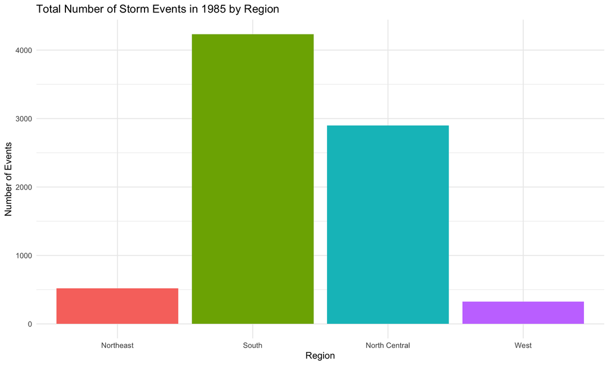

### Box Plot of Events per Region

The box plot below displays the distribution of storm events in 1985 by region. The South region shows a wide range of event counts with some outliers, indicating variability in storm activity.

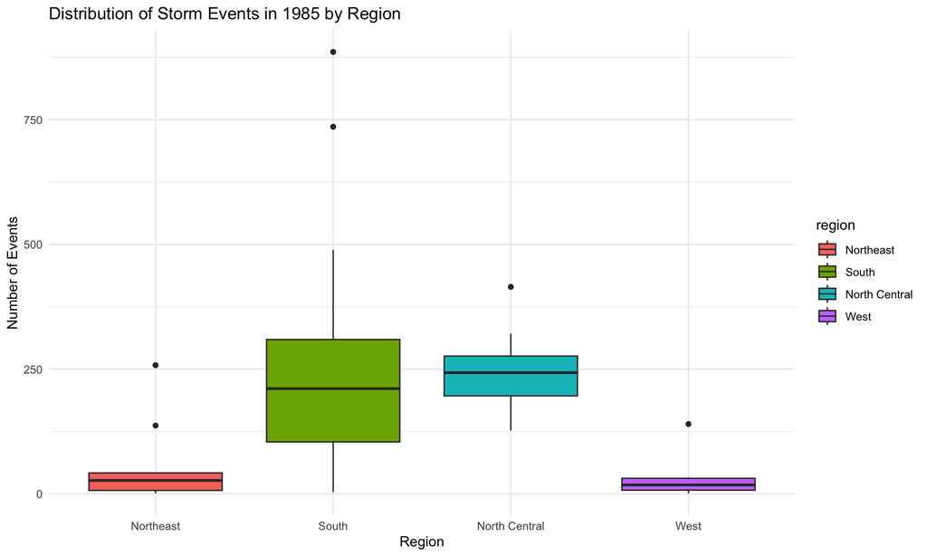

### Histogram of Event Distribution

The histogram below shows the distribution of the number of events in 1985. The majority of states experienced fewer than 500 events, with some states experiencing significantly higher numbers.

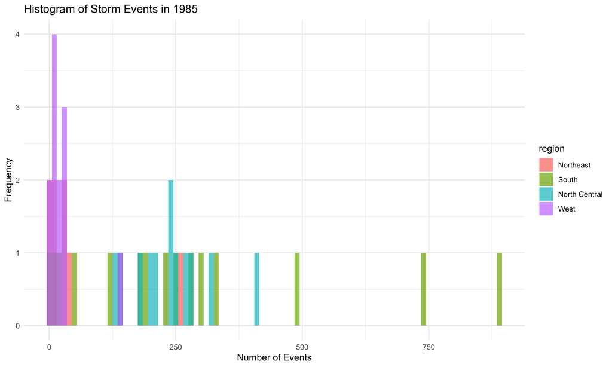

### Scatter Plot of Events by State Area

The scatter plot below visualizes the number of events by state area. There is no clear relationship between the size of the state and the number of storm events.

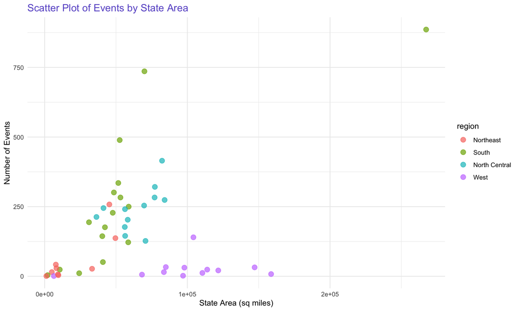

### Heatmap of Events by State and Month

The heatmap below shows the number of storm events by state and month in 1985. This visualization helps to identify patterns and peak periods of storm activity for each state.

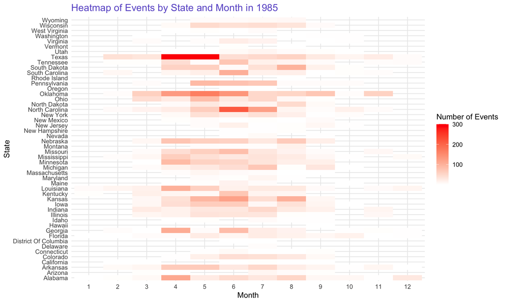

### Pie Chart of Event Types

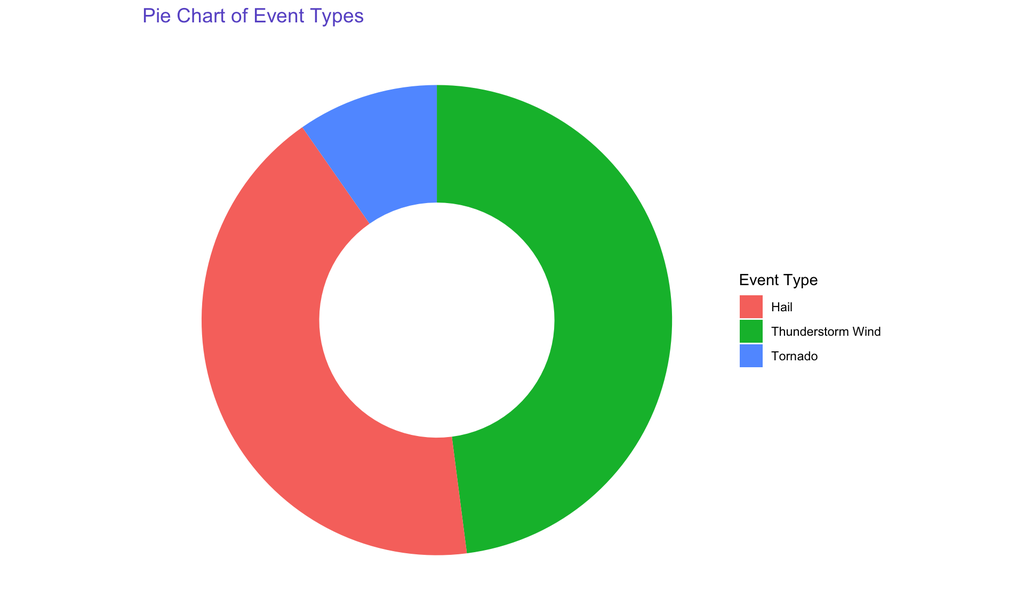

### Seasonal Patterns

The analysis of seasonal patterns helps to understand how storm events are distributed throughout the year.

##### Defining Seasons

To analyze the seasonal patterns, the data was divided into four seasons:

Winter: January, February, December

Spring: March, April, May

Summer: June, July, August

Fall: September, October, November

The bar plot below shows the number of storm events in 1985 for each season. Summer had the highest number of storm events, followed by Spring.

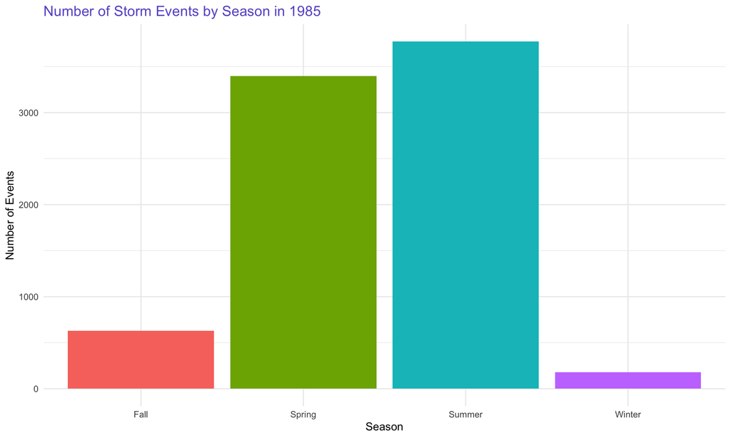

### Line Plot of Events Over Time

The line plot below shows the number of storm events each month in 1985. The peak is observed in June, indicating increased storm activity during early summer.

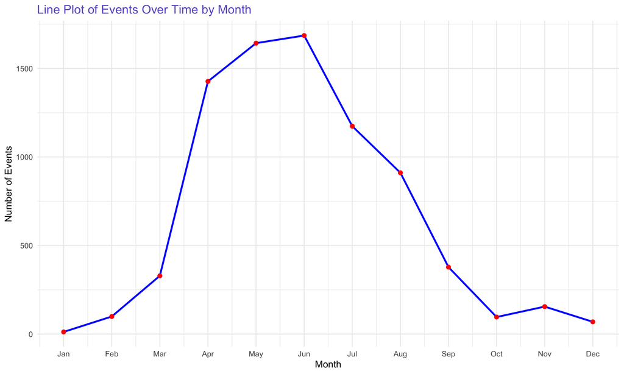